# Data Visualization Project

Alex Rivera Cruz

12/22/2019

First, we have to setup installing and loading the necessary packages.

# Part 1: Exploratory Data Analysis

The data we’ll be using for this part of the project were downloaded from [kaggle](https://www.kaggle.com/aaronschlegel/seattle-pet-licenses/data), and include information about “pet licenses issued by the Seattle Animal Shelter between 2005 and early 2017.” We’ll be exploring these data and generating a few exploratory plots in the first part of the project.

## The Data

First, we’ll read the data in from our `data/raw_data` directory.

```r
pets <- read.csv("dataviz_project/data/raw_data/seattle_pet_licenses.csv", stringsAsFactors = FALSE)
```

## Explore the Data

Now, we have to explore the data.

```r
## Include code here to explore the data
## and answer the questions in the exercise
head(pets)
```

```
##   animal_s_name      license_issue_date license_number
## 1          Ozzy 2005-03-29T00:00:00.000         130651
## 2          Jack 2009-12-23T00:00:00.000         898148
## 3        Ginger 2006-01-20T00:00:00.000          29654
## 4        Pepper 2006-02-07T00:00:00.000          75432
## 5          Addy 2006-08-04T00:00:00.000         729899
## 6        Rustie 2007-07-24T00:00:00.000         437433
##                       primary_breed     secondary_breed species zip_code
## 1 Dachshund, Standard Smooth Haired                         Dog    98104
## 2              Schnauzer, Miniature        Terrier, Rat     Dog    98107
## 3                 Retriever, Golden Retriever, Labrador     Dog    98117
## 4                              Manx                 Mix     Cat    98103
## 5                 Retriever, Golden                         Dog    98105
## 6 Dachshund, Standard Smooth Haired                         Dog    98108
```

```r
nrow(pets)
```

```
## [1] 66042
```

```r
length(unique(pets$animal_s_name))
```

```
## [1] 15796
```

```r
length(unique(pets$species))
```

```
## [1] 3
```

```r
unique(pets$species)
```

```
## [1] "Dog"       "Cat"       "Livestock"
```

## Visualize the Data

Creating a Bar Plot of species in the data.

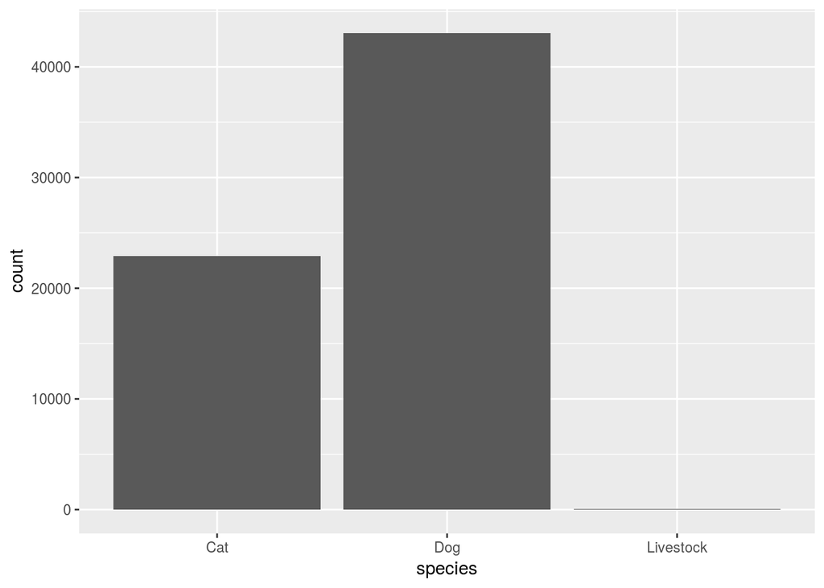

```r
## visual breakdown of how many of each species
## are included in the dataset
ggplot(pets) +
  geom_bar(aes(x=species))
```

Creating a table of Most common cat name:

```r
## Table: Most frequent Cat Name
pets %>%
  filter(species == "Cat", animal_s_name != "") %>%
  group_by(animal_s_name) %>%
  summarise(n = n()) %>%
  arrange(-n) %>%
  top_n(n = 10) %>%
  knitr::kable(., caption = "Top 10 Cat Names in Seattle")
```

Top 10 Cat Names in Seattle

| animal_s_name | n |
| --- | --- |
| Lucy | 150 |
| Max | 120 |
| Luna | 119 |
| Bella | 113 |
| Oliver | 108 |
| Charlie | 99 |
| Lily | 93 |
| Jack | 87 |
| Sophie | 81 |
| Shadow | 69 |

Creating a table of Most common dog name:

```r
## Table: Most frequent Dog Name
## ADD CODE!
pets %>%
  filter(species == "Dog", animal_s_name != "") %>%
  group_by(animal_s_name) %>%
  summarise(n = n()) %>%
  arrange(-n) %>%
  top_n(n = 10) %>%
  knitr::kable(., caption = "Top 10 Dog Names in Seattle")
```

Top 10 Dog Names in Seattle

| animal_s_name | n |
| --- | --- |
| Lucy | 416 |
| Charlie | 348 |
| Bella | 338 |
| Buddy | 256 |
| Daisy | 256 |
| Max | 254 |
| Molly | 243 |
| Luna | 242 |
| Lola | 232 |
| Maggie | 226 |

Creating a Line Plot to see the registration of licese across the time.

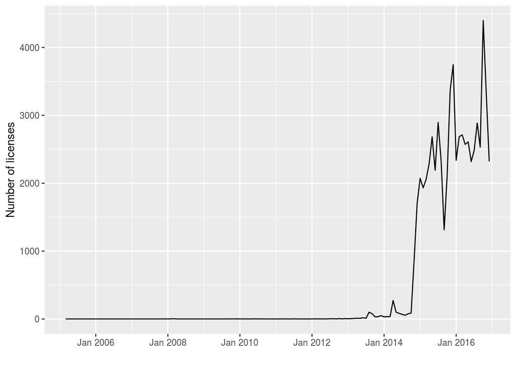

```r
## add date and ym columns
pets$date <- lubridate::ymd_hms(pets$license_issue_date)
pets$ym <- as.yearmon(pets$date, "%y%m")

## how the number of licenses recorded has changed over time
pets %>%
  ## group by yearmonth (`ym`)
  group_by(ym) %>%
  ## count number within each group
  summarise(n=n()) %>%
  ggplot(., aes(ym, n)) +
  ## geom name for line chart
  geom_line() +
  scale_x_yearmon() +
  xlab("") +
  ylab("Number of licenses")
```

Creating a table to see most common Dog Breed

```r
### Explore the data -- create your own plot!

pets %>%
  filter(species == "Dog", primary_breed != "") %>%
  group_by(primary_breed) %>%
  summarise(n = n()) %>%
  arrange(-n) %>%
  top_n(n = 10) %>%
  knitr::kable(., caption = "Top 10 Dog primary breed in Seattle")
```

Top 10 Dog primary breed in Seattle

| primary_breed | n |
| --- | --- |
| Retriever, Labrador | 6350 |
| Retriever, Golden | 2321 |
| Chihuahua, Short Coat | 2134 |
| German Shepherd | 1259 |
| Australian Shepherd | 1184 |
| Terrier | 1119 |
| Border Collie | 991 |
| Terrier, American Pit Bull | 973 |
| Poodle, Miniature | 929 |
| Shih Tzu | 828 |

# Part 2: Explanatory Data Analysis

The data used in this part of the project were dowloaded from [FiveThirtyEight](https://data.fivethirtyeight.com/) - `steak-survey`. They were originally used in the article: [How Americans Like Their Steak](https://fivethirtyeight.com/features/how-americans-like-their-steak/). The goal of this part of the project will be to recreate the data visualization used in this article.

## The Data

Reading the data.

```r
## read in the data
steak <- read.csv("dataviz_project/data/raw_data/steak-risk-survey.csv", stringsAsFactors = FALSE) %>%
  ## remove first row which just includes the word "Response" in each column
  slice(2:n())
```

## Explore the Data

Exploring tha dataset of steak.

```r
## Include code here to explore the data
## and answer the questions in the exercise
head(steak)
```

```
##   RespondentID
## 1   3237565956
## 2   3234982343
## 3   3234973379
## 4   3234972383
## 5   3234958833
## 6   3234955240
##   Consider.the.following.hypothetical.situations...br.In.Lottery.A..you.have.a.50..chance.of.success..with.a.payout.of..100...br.In.Lottery.B..you.have.a.90..chance.of.success..with.a.payout.of..20...br..br.Assuming.you.have..10.to.bet..would.you.play. ...
## 1                                                                                                                                                                                                                                                      Lottery B
## 2                                                                                                                                                                                                                                                      Lottery A
## 3                                                                                                                                                                                                                                                      Lottery A
## 4                                                                                                                                                                                                                                                      Lottery B
## 5                                                                                                                                                                                                                                                      Lottery B
## 6                                                                                                                                                                                                                                                      Lottery A
##   Do.you.ever.smoke.cigarettes. Do.you.ever.drink.alcohol. Do.you.ever.gamble.
```

[output cut: 34 more lines]

```r
nrow(steak)
```

```
## [1] 550
```

```r
colnames(steak)
```

```
##  [1] "RespondentID"
##  [2] "Consider.the.following.hypothetical.situations...br.In.Lottery.A..you.have.a.50..chance.of.success..with.a.payout.of..100...br.In.Lottery.B..you.have.a.90..chance.of.success..with.a.payout.of..20...br..br.Assuming.you.have..10.to.bet..would.you.play.Lottery.A.or.Lottery.B."
##  [3] "Do.you.ever.smoke.cigarettes."
##  [4] "Do.you.ever.drink.alcohol."
##  [5] "Do.you.ever.gamble."
##  [6] "Have.you.ever.been.skydiving."
##  [7] "Do.you.ever.drive.above.the.speed.limit."
##  [8] "Have.you.ever.cheated.on.your.significant.other."
##  [9] "Do.you.eat.steak."
## [10] "How.do.you.like.your.steak.prepared."
## [11] "Gender"
## [12] "Age"
## [13] "Household.Income"
## [14] "Education"
## [15] "Location..Census.Region."
```

```r
sum(steak$Do.you.eat.steak.=="Yes")
```

```
## [1] 430
```

```r
unique(steak$How.do.you.like.your.steak.prepared.)
```

```
## [1] ""            "Medium rare" "Rare"        "Medium"      "Medium Well"
## [6] "Well"
```

## Wrangle the Data

Wrangling the data to work better.

```r
## wrangle the steak data set
pref <- steak %>%
  mutate(steak_pref = factor(How.do.you.like.your.steak.prepared.,
                             levels = c("Well",
                                        "Medium Well",
                                        "Medium",
                                        "Medium rare",
                                        "Rare"))) %>%
  filter(steak_pref != "") %>%
  group_by(steak_pref) %>%
  summarise(n = n()) %>%
  mutate(prop = n / sum(n))

dim(pref)
```

```
## [1] 5 3
```

```r
pref
```

```
## # A tibble: 5 x 3
##   steak_pref      n   prop
##   <fct>       <int>  <dbl>
## 1 Well           36 0.0833
## 2 Medium Well    75 0.174
## 3 Medium        132 0.306
## 4 Medium rare   166 0.384
## 5 Rare           23 0.0532
```

## Visualize the Data

Generating the explanatory plot about the preferences of steak wellness.

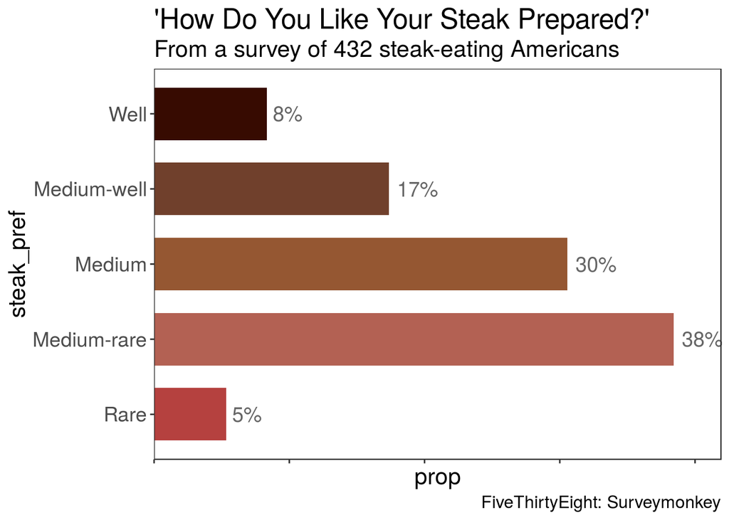

```r
## generate the plot
p <- ggplot(pref) +
  ## specify you want to generate a bar chart
  geom_bar(aes(x = steak_pref, y = prop, fill = steak_pref),
                stat = 'identity',
                width = 0.7) +
  ## this adds text labels (you don't have to change anything here)
  geom_text(aes(label = paste0(as.integer(prop*100),"%"),
                x = steak_pref,
                y = prop),
            stat= "identity",
            hjust = -0.2,
            size = 5,
            color = "grey40") +
  ## flip coordinates to make horizontal box plot
  coord_flip() +
  ## change the colors of the bars
  scale_fill_manual(values = c("#370B01",
                           "#70402C",
                           "#955732",
                           "#B36153",
                           "#B5413F")) +
  ## change the scale/labels of the steak-wellness variable (x-axis)
  scale_x_discrete(limits = levels(fct_rev(pref$steak_pref)),
                labels = c("Well",
                           "Medium Well" = "Medium-well",
                           "Medium",
                           "Medium rare"="Medium-rare",
                           "Rare")) +
  ## change the scale/labels of the percent axis (y-axis)
  scale_y_continuous(labels = scales::percent,
                expand = c(mult = c(0,0),
                           add = c(0,0.035))) +
  ## change the title, subtitle, and caption
  labs(title="'How Do You Like Your Steak Prepared?'",
                subtitle="From a survey of 432 steak-eating Americans",
                caption="FiveThirtyEight: Surveymonkey") +
  ## change the theme (use ggthemes)
  theme_bw() +
  ## fine tune the theme
  theme(axis.text = element_text(size = 14),
                title = element_text(size = 16),
                legend.position="none",
                plot.caption=element_text(size = 12),
                panel.grid.major = element_blank(),
                panel.grid.minor = element_blank(),
                axis.text.x = element_blank()
  )

p
```

## Save the Plot

Saving the created plot in explanatory figures directory

```r
## save plot to figures/explanatory_figures directory
ggsave(plot = p, filename = "steak_R.png",path = "dataviz_project/figures/explanatory_figures", width = 8, height = 4)
```

## Visualize the Data

Generating the explanatory plot about the of House Income.

```r
### Explore the data -- create your own plot!
person_income <- steak %>%
  mutate(income = factor(Household.Income,
                             levels = c("$0 - $24,999",
                                        "$25,000 - $49,999",
                                        "$50,000 - $99,999",
                                        "$100,000 - $149,999",
                                        "$150,000+"))) %>%
  filter(income != "") %>%
  group_by(income) %>%
  summarise(n = n()) %>%
  mutate(prop = n / sum(n))

head(person_income)
```

```
## # A tibble: 5 x 3
##   income                  n  prop
##   <fct>               <int> <dbl>
## 1 $0 - $24,999           51 0.119
## 2 $25,000 - $49,999      77 0.179
## 3 $50,000 - $99,999     172 0.4
## 4 $100,000 - $149,999    76 0.177
## 5 $150,000+              54 0.126
```

[figure not shown]

```r
pnew <- ggplot(person_income) +
  ## specify you want to generate a bar chart
  geom_bar(aes(x = income, y = prop, fill = income),
                stat = 'identity',
                width = 0.7) +
  ## this adds text labels (you don't have to change anything here)
  geom_text(aes(label = paste0(as.integer(prop*100),"%"),
                x = income,
                y = prop),
            stat= "identity",
            hjust = -0.2,
            size = 5,
            color = "grey40") +
  ## flip coordinates to make horizontal box plot
  coord_flip() +
  ## change the colors of the bars
  scale_fill_manual(values = c("#370B01",
                           "#70402C",
                           "#955732",
                           "#B36153",
                           "#B5413F")) +
  ## change the scale/labels of the income variable (x-axis)
  scale_x_discrete(limits = levels(fct_rev(person_income$income)),
                labels = c("$0 - $24,999",
                            "$25,000 - $49,999",
                            "$50,000 - $99,999",
                            "$100,000 - $149,999",
                            "$150,000+")) +
  ## change the scale/labels of the percent axis (y-axis)
  scale_y_continuous(labels = scales::percent,
                expand = c(mult = c(0,0),
                           add = c(0,0.035))) +
  ## change the title, subtitle, and caption
  labs(title="'What are the incomes oh the people?'",
                subtitle="From a survey of 550 Americans",
                caption="FiveThirtyEight: Surveymonkey") +
  ## change the theme (use ggthemes)
  theme_bw() +
  ## fine tune the theme
  theme(axis.text = element_text(size = 14),
                title = element_text(size = 16),
                legend.position="none",
                plot.caption=element_text(size = 12),
                panel.grid.major = element_blank(),
                panel.grid.minor = element_blank(),
                axis.text.x = element_blank()
  )

pnew
```

## Save this plot

Saving the created plot.

```r
## save plot to figures/explanatory_figures directory
ggsave(plot = pnew, filename = "income.png", path = "dataviz_project/figures/explanatory_figures", width = 8, height = 4)
```